# Lecture 19: Chi-Square Test

Data Analysis for Psychology in R 1

Tom Booth

Click for slides

## Today

- Discuss two forms of $\chi^2$ tests.
  - Goodness of fit
  - Test of independence
- We will consider:
  - When to use each
  - Data requirements
  - Calculation
  - Interpretation
  - Assumptions

## Learning objectives

- Understand when to use goodness of fit and tests of independence.
- Understand the logic of the underlying calculations
- Understand the structure of the R-code for completing the tests.

## Purpose

- $\chi^2$ goodness of fit test
  - The primary purpose is to test whether the collected data (observed frequencies) are consistent with a hypothesized/known distribution (expected frequencies).
- $\chi^2$ test of independence:
  - We have 2 categorical variables, drawn from a single population.
  - We want to know if the variables are independent or not.
  - If the category membership is dependent, then knowing what category someone is in on variable 1, helps us predict what category they would be in for variable 2.

## Data Requirements

- $\chi^2$ goodness of fit test
  - Single categorical variable
- $\chi^2$ test of independence:
  - Two categorical variables.

## Example: Goodness of fit

- Suppose we are interested in the distribution of students across three final year psychology options (Social, Differential, Developmental).
- We have data from 2014-15, and we want to know if the distribution is the same in 2015-16.

## Data

```r
head(class)
# A tibble: 6 x 2
  ID    course
  <chr> <fct>
1 ID1   Differential
2 ID2   Social
3 ID3   Social
4 ID4   Social
5 ID5   Social
6 ID6   Developmental
```

- `ID` = Unique ID variable
- `course` = factor with 3 levels (Social, Differential, Developmental)

## Observed frequencies

```r
tab1 <- class %>%
  group_by(course) %>%
  tally()
```

```r
tab1
# A tibble: 3 x 2
  course            n
  <fct>         <int>
1 Differential     28
2 Social           62
3 Developmental    60
```

## Relative frequencies

- In 2014-15, the department had the following proportions:
  - Social = 0.50, or 50%
  - Differential = 0.30, or 30%
  - Developmental = 0.20, or 20%

```r
tab1 <- tab1 %>%
  transmute(
    course = course,
    relative = c(0.30, 0.50, 0.20),
    observed = n
  )
```

```r
tab1
# A tibble: 3 x 3
  course        relative observed
  <fct>            <dbl>    <int>
1 Differential       0.3       28
2 Social             0.5       62
3 Developmental      0.2       60
```

## Expected frequencies

- Given this, and a total number of students (n=150) for the current year, we can calculate the expected frequencies for each area.
  - $Expected = Relative*N$

## Put it together

```r
tab1 <- tab1 %>%
  mutate(
    expected = relative*sum(observed)
  )
```

```r
tab1
# A tibble: 3 x 4
  course        relative observed expected
  <fct>            <dbl>    <int>    <dbl>
1 Differential       0.3       28       45
2 Social             0.5       62       75
3 Developmental      0.2       60       30
```

## Hypotheses

$$\begin{matrix}
H_0 = P(0.20, 0.50, 0.30) \\
H_1 \neq P(0.20, 0.50, 0.30)
\end{matrix}$$

- $H_0$ says that the data follow a specific and known pattern or probabilities (frequencies)
- $H_1$ says they don’t

## Test statistic

$$\chi^2 = \sum_{i=1}^{k} \frac{(E_i - O_i)^2}{E_i}$$

- $E_i$ = expected frequencies
- $O_i$ = observed frequencies
- $\sum_{i=1}^{k}$ = do the calculation starting from cell 1 through to cell $k$ (k=number groups) and add them up.

## Null Distribution

- Sampling distribution for $\chi^2$ test is a $\chi^2$ distribution.
- $\chi^2$ distribution describes the distribution of the sum of $k$ squared independent standard normal variables.
  - Huh?

$$\chi^2 = \sum_{i=1}^{k} \frac{(E_i - O_i)^2}{E_i}$$

- Parameter of the $\chi^2$ distribution is degrees of freedom (df)
  - Just like $t$-test.
- df are determined by the number of categories ($k$)
- Goodness of fit test has $k-1$ degrees of freedom.
  - Why?

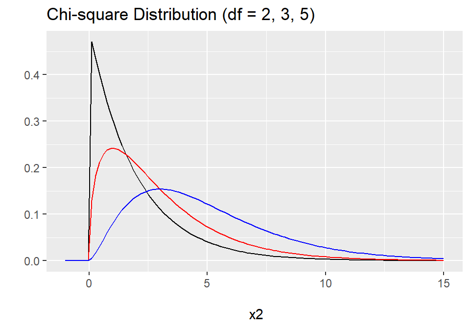

## Calculation

```r
tab1 <- tab1 %>%
  mutate(
    step1 = expected - observed,
    step2 = step1^2,
    step3 = step2/expected
  )
tab1
# A tibble: 3 x 7
  course        relative observed expected step1 step2 step3
  <fct>            <dbl>    <int>    <dbl> <dbl> <dbl> <dbl>
1 Differential       0.3       28       45    17   289  6.42
2 Social             0.5       62       75    13   169  2.25
3 Developmental      0.2       60       30   -30   900 30
```

- Step1 = $E_i - O_i$
- Step2 = $(E_i - O_i)^2$
- Step3 = $\frac{(E_i - O_i)^2}{E_i}$
- Last step is to sum the values for step 3 to get the $\chi^2$

```r
x2 <- sum(tab1$step3)
x2
[1] 38.67556
```

## Is my test significant?

- $\chi^2$ = 38.6755556
- Degrees of freedom = 3-1 = 2
- $\alpha$ = 0.05

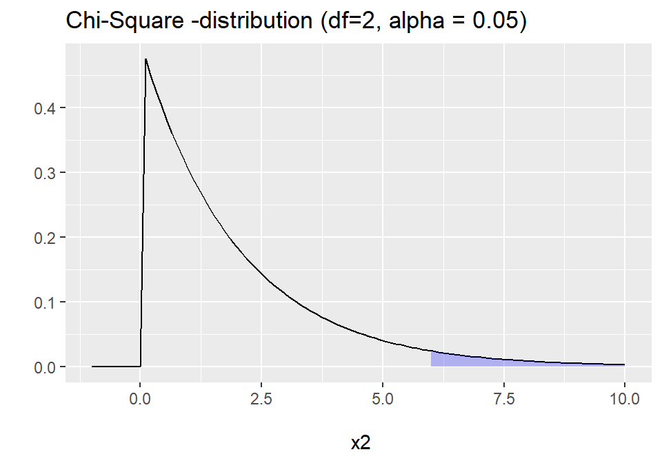

```r
tibble(
  CritValue = round(qchisq(0.95, 2),2),
  Exactp = round(2*(1-pchisq(x2, 2)),5)
)
# A tibble: 1 x 2
  CritValue Exactp
      <dbl>  <dbl>
1      5.99      0
```

## In R

```r
gof_res <- chisq.test(tab1$observed, p = c(0.3, 0.5, 0.2))
gof_res

    Chi-squared test for given probabilities

data:  tab1$observed
X-squared = 38.676, df = 2, p-value = 3.997e-09
```

## Write up

A $\chi^2$ goodness of fit test was conducted in order to investigate whether the distribution of students across Social, Developmental and Differential classes was equivalent in 2014- 15 and 2015-16. The goodness of fit test was significant ($\chi^2$(2) = 38.68, $p$<.05) and thus the null hypothesis was rejected. The distribution of student’s across courses differs between the two academic years.

## Example: Independence

- I have conducted an experiment with three conditions (n=120, 40 per group)
- I want to check whether my participants are equally distributed based on some demographic variables.
  - Let’s focus on whether English is participants first language
- Recall from an experimental design perspective, I want such things to be randomized across my groups.
  - So I would expect an even distribution.

```r
head(exp)
# A tibble: 6 x 3
  ID    condition lang
  <chr> <chr>     <chr>
1 ID1   control   Yes
2 ID2   control   No
3 ID3   control   No
4 ID4   control   Yes
5 ID5   control   No
6 ID6   control   No
```

- `ID` = Unique ID variable
- `condition` = experimental conditions (control, group1, group2)
- `lang` = binary Yes/No for English as first language

## Tabular format

- It can be very useful to display data for two categorical variables as a contingency table.

```r
tabs <- addmargins(table(exp$condition, exp$lang))
tabs

           No Yes Sum
  control  19  21  40
  group1   31   9  40
  group2   15  25  40
  Sum      65  55 120
```

## Visualizing Data: Mosaic Plot

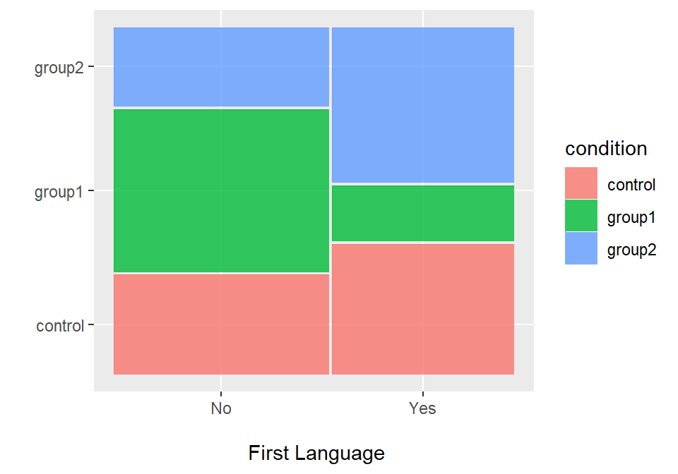

```r
## install.packages("ggmosaic")
## library(ggmosaic)

ggplot(data = exp) +
  geom_mosaic(aes(x = product(condition, lang), fill = condition)) +
  labs(x = "\n First Language", y = "")
```

- We can also show the same data as a mosaic plot.

$$\begin{matrix}
H_0: P_{11} = P_{12}, P_{21} = P_{22}, P_{31} = P_{32} \\
H_1: P_{11} \neq P_{12} | P_{21} \neq P_{22} | P_{31} \neq P_{32}
\end{matrix}$$

- In words
  - $H_0$ says the proportion of each cell in each row are equal.
  - $H_1$ says at least one of these pairs are not equal.
- The test statistic looks much the same as the statistic for the GoF test.

$$\chi^2 = \sum_{i=1}^{r}\sum_{i=1}^{c} \frac{(\hat{E_{ij}} - O_{ij})^2}{\hat{E_{ij}}}$$

- What is different?
  - $\sum_{i=1}^{r}\sum_{i=1}^{c}$ simply means sum the quantities for all cells in all rows (r) and columns (c)
  - But why $\hat{E_{ij}}$? Why the hat?
- Remember in the GoF test we knew the expected frequencies because we had known proportions and known sample size.
  - Here we do not have that.
- So we have to estimate the expected frequencies from the data.
  - Hence we use $\hat{E}$ to show this is an estimate.

$$\hat{E_{ij}} = \frac{R_iC_j}{N}$$

## Calculation: Controls-No

```
           No Yes Sum
  control  19  21  40
  group1   31   9  40
  group2   15  25  40
  Sum      65  55 120
```

$$\hat{E_{11}} = \frac{R_1C_1}{N} = \frac{40*65}{120} = \frac{2600}{120} = 21.67 \\$$

$$\frac{(\hat{E_{11}} - O_{11})^2}{\hat{E_{11}}} = \frac{(21.67 - 19)^2}{21.67} = \frac{7.1289}{21.67} = 0.33$$

- Again, we evaluate the $\chi^2$ test of independence statistic against the $\chi^2$-distribution.
- Here:

$$df = (r-1)(c-1)$$

- Note, $r$ and $c$ are just the number of levels for each categorical variable.
- In our example $(r-1)(c-1)=(3-1)(2-1)=2*1=2$
  - Thus using the same $\alpha$=0.05, we would have the same critical value = 5.99

```r
con <- table(exp$condition, exp$lang)
ind_res <- chisq.test(con)
ind_res

    Pearson's Chi-squared test

data:  con
X-squared = 13.964, df = 2, p-value = 0.0009286
```

A $\chi^2$ test of independence was performed to examine whether the distribution of English first language speakers was consistent across experimental conditions (n=120). The relation between these variables was significant ($\chi^2$(2) = 13.96, p <.05). Therefore, we reject the null hypothesis.

## Output

- Here I want to make brief comment about analysis objects.
- The object `ind_res` contains the output of our analysis.
  - This has lots of elements to it.
- We can view and work with these by using the $ sign

```r
names(ind_res)
[1] "statistic" "parameter" "p.value"   "method"    "data.name" "observed"
[7] "expected"  "residuals" "stdres"
```

## Residuals

- For example, lets look at the residuals.
- The Pearson residuals tell us which cells in the contingency table had the greatest differences.

```r
ind_res$residuals

                  No        Yes
  control -0.5728919  0.6227992
  group1   2.0051216 -2.1797970
  group2  -1.4322297  1.5569979
```

## Assumptions

- Sufficiently large N to approximate a normal sampling distribution
  - We saw last semester this actually begins to happen pretty fast.
- Expected and observed cell frequencies are sufficiently large.
  - If either drop below 5, then there is not really enough data.
- Each observation appears in only 1 cell.
  - Data are independent.
  - If data are dependent, we can use a McNemar test.

## Yate’s correction

- An aside:
  - Our chi-square test only approximates a chi-square sampling distribution.
  - When we have a 2x2 table with df=1, it turns out this approximation is not very good.
  - So for 2x2 tables we apply Yate’s continuity correction.
  - This subtracts 0.5 from each cell deviation.
  - It is the default in R when we have a 2x2 table.

## Effect size

- Three possibilities:
  - Phi coefficient (for 2x2 tables)
  - Odds ratios
  - Cramer’s V
- We will not discuss these much this year as we will come back to odds ratios in year 2.
  - Equations and code are shown in the full calculation additional slides.

## Tasks for this week…

1. Finish tasks from last week.
2. Quiz 19: All $t$-tests
   - Today at 17:00.
   - Close Monday 3rd at 17:00

## Full calculations

```r
ind_res

    Pearson's Chi-squared test

data:  con
X-squared = 13.964, df = 2, p-value = 0.0009286
```

- Let’s do all the steps to calculate $\chi^2$ and the exact p-value.
- Let’s start with the expected values

$$\hat{E_{ij}} = \frac{R_iC_j}{N}$$

```
           No Yes Sum
  control  19  21  40
  group1   31   9  40
  group2   15  25  40
  Sum      65  55 120
```

$$\hat{E_{11}} = \frac{R_1C_1}{N} = \frac{40*65}{120} = \frac{2600}{120} = 21.67 \\$$

- As we have the same number of participants in each condition, this is also the expected value for $\hat{E_{21}}$ and $\hat{E_{31}}$

```
           No Yes Sum
  control  19  21  40
  group1   31   9  40
  group2   15  25  40
  Sum      65  55 120
```

$$\hat{E_{12}} = \frac{R_1C_2}{N} = \frac{40*55}{120} = \frac{2200}{120} = 18.33 \\$$

- As we have the same number of participants in each condition, this is also the expected value for $\hat{E_{22}}$ and $\hat{E_{23}}$
- We can check these against the information in the output to the R analysis

```r
ind_res$expected

                No      Yes
  control 21.66667 18.33333
  group1  21.66667 18.33333
  group2  21.66667 18.33333
```

- Now, the $\chi^2$

```
           No Yes Sum
  control  19  21  40
  group1   31   9  40
  group2   15  25  40
  Sum      65  55 120
```

$$\frac{(\hat{E_{11}} - O_{11})^2}{\hat{E_{11}}} = \frac{(21.67 - 19)^2}{21.67} = \frac{7.1289}{21.67} = 0.33$$

- Now, the $\chi^2$

```
           No Yes Sum
  control  19  21  40
  group1   31   9  40
  group2   15  25  40
  Sum      65  55 120
```

$$\frac{(\hat{E_{21}} - O_{21})^2}{\hat{E_{21}}} = \frac{(21.67 - 31)^2}{21.67} = \frac{87.05}{21.67} = 4.02$$

- Now, the $\chi^2$

```
           No Yes Sum
  control  19  21  40
  group1   31   9  40
  group2   15  25  40
  Sum      65  55 120
```

$$\frac{(\hat{E_{31}} - O_{31})^2}{\hat{E_{31}}} = \frac{(21.67 - 15)^2}{21.67} = \frac{44.49}{21.67} = 2.05$$

- Now, the $\chi^2$

```
           No Yes Sum
  control  19  21  40
  group1   31   9  40
  group2   15  25  40
  Sum      65  55 120
```

$$\frac{(\hat{E_{12}} - O_{12})^2}{\hat{E_{12}}} = \frac{(18.33 - 21)^2}{18.33} = \frac{7.1289}{18.33} = 0.39$$

- Now, the $\chi^2$

```
           No Yes Sum
  control  19  21  40
  group1   31   9  40
  group2   15  25  40
  Sum      65  55 120
```

$$\frac{(\hat{E_{22}} - O_{22})^2}{\hat{E_{22}}} = \frac{(18.33 - 9)^2}{18.33} = \frac{87.05}{18.33} = 4.75$$

- Now, the $\chi^2$

```
           No Yes Sum
  control  19  21  40
  group1   31   9  40
  group2   15  25  40
  Sum      65  55 120
```

$$\frac{(\hat{E_{32}} - O_{32})^2}{\hat{E_{32}}} = \frac{(18.33 - 25)^2}{18.33} = \frac{44.49}{18.33} = 2.43$$

- Last step is to add them up:

$$\chi^2 = \sum_{i=1}^{r}\sum_{i=1}^{c} \frac{(\hat{E_{ij}} - O_{ij})^2}{\hat{E_{ij}}}$$

```r
x2i <- 0.33 + 4.02 + 2.05 + 0.39 + 4.75 + 2.43
x2i
[1] 13.97
```

- And check against the R results (tiny bit of rounding error)

```r
ind_res

    Pearson's Chi-squared test

data:  con
X-squared = 13.964, df = 2, p-value = 0.0009286
```

- And the p-value

```r
1 - pchisq(13.964, 2)
[1] 0.0009284445
```

- The Pearson’s residuals are calculated as:

$$Residual_{ij} = \frac{(E_{ij} - O_{ij})}{\sqrt{E_{ij}}}$$

- So let’s do one residual and then look at the output of our analysis:

$$Residual_{11} = \frac{(E_{11} - O_{11})}{\sqrt{E_{1}}} = \frac{(21.67 - 19)}{\sqrt{21.67}} = \frac{2.67}{4.655105} = 0.57$$

```r
ind_res$residuals

                  No        Yes
  control -0.5728919  0.6227992
  group1   2.0051216 -2.1797970
  group2  -1.4322297  1.5569979
```

- Hold on….why is our calculation positive, and the R results negative?
- This is just an interpretation point.
- In our calculation, we have used $E_{ij} - O_{ij}$
- If instead we calculate $O_{ij} - E_{ij}$, then we would get the same absolute value but negative.
- Why not try it.
- So the last thing is to quickly show the equations for the effect size measures.

$$Phi = \sqrt{\frac{\chi^2}{N}}$$

$$CramerV = \sqrt{\frac{\chi^2}{N*min(r-1,c-1)}}$$

- Cramer’s V generalizes phi to larger contingency tables.